# DMA - Homework 5

Viet Ba Mai

12 listopada 2016

# Description

Given is Walmart’s transactional dataset. The task is to classify customer shopping trips The goal of this homework is to create a model which results will be within the top 150 from the Kaggle leaderboard: https://www.kaggle.com/c/walmart-recruiting-trip-type-classification/leaderboard

```r
library(caret)
library(dplyr)
library(tidyr)
library(randomForest)
import <- read.csv(file.path(file.path(getwd(), "data"), "train.csv"), header=TRUE, sep=",", encoding="UTF-8")
head(import)
```

```
##   TripType VisitNumber Weekday         Upc ScanCount DepartmentDescription
## 1      999           5  Friday 68113152929        -1    FINANCIAL SERVICES
## 2       30           7  Friday 60538815980         1                 SHOES
## 3       30           7  Friday  7410811099         1         PERSONAL CARE
## 4       26           8  Friday  2238403510         2 PAINT AND ACCESSORIES
## 5       26           8  Friday  2006613744         2 PAINT AND ACCESSORIES
## 6       26           8  Friday  2006618783         2 PAINT AND ACCESSORIES
##   FinelineNumber
## 1           1000
## 2           8931
## 3           4504
## 4           3565
## 5           1017
## 6           1017
```

```r
#test <- read.csv(file.path(file.path(getwd(), "data"), "test.csv"), header=TRUE, sep=",", encoding="UTF-8")
```

In the competition both training and testing datasets are given, but the testing set does not have the target variable with which checking the performance would be possible, so for the purpose of the homework the training and testing sets will be partitioned from the original train set.

# Data fields

The following are field descriptions taken from https://www.kaggle.com/c/walmart-recruiting-trip-type-classification/data?train.csv.zip :

- **TripType** - a categorical id representing the type of shopping trip the customer made. This is the ground truth that you are predicting. TripType_999 is an “other” category.
- **VisitNumber** - an id corresponding to a single trip by a single customer. It is non-predictive hence will be excluded.
- **Weekday** - the weekday of the trip.
- **Upc** - the UPC number of the product purchased.
- **ScanCount** - the number of the given item that was purchased. A negative value indicates a product return.
- **DepartmentDescription** - a high-level description of the item’s department.
- **FinelineNumber** - a more refined category for each of the products, created by Walmart.

[output not shown]

# Creating new features

And also I will create features by spreading the `DepartmentDescription`.

```r
data = import %>%
  group_by(VisitNumber) %>%
  summarise(TripType = head(TripType,1),
            Day = unique(setNames(0:6, c("Sunday", "Monday", "Tuesday", "Wednesday", "Thursday", "Friday", "Saturday"))[Weekday])[1],
            BoughtProducts = sum(ScanCount >= 0),
            ReturnedProducts = sum(ScanCount < 0),
            TotalProducts = sum(ScanCount),
            DepartmentCount = n_distinct(DepartmentDescription),
            FinelineCount = n_distinct(FinelineNumber)
            )
# prop.table(table(tmp$Day))
# prop.table(table(data$Day))
head(data)
```

```
## # A tibble: 6 × 8
##   VisitNumber TripType   Day BoughtProducts ReturnedProducts TotalProducts
##         <int>    <int> <int>          <int>            <int>         <int>
## 1           5      999     0              0                1            -1
## 2           7       30     0              2                0             2
## 3           8       26     0             21                2            28
## 4           9        8     0              3                0             3
## 5          10        8     0              3                0             3
## 6          11       35     0              4                0             4
## # ... with 2 more variables: DepartmentCount <int>, FinelineCount <int>
```

```r
dataDepartments = import %>%
  group_by(TripType, VisitNumber, DepartmentDescription) %>%
  summarise(count = n()) %>%
  spread(DepartmentDescription, count, fill=0)
head(dataDepartments)
```

```
## Source: local data frame [6 x 71]
## Groups: TripType, VisitNumber [6]
##
##   TripType VisitNumber `1-HR PHOTO` ACCESSORIES AUTOMOTIVE BAKERY
##      <int>       <int>        <dbl>       <dbl>      <dbl>  <dbl>
## 1        3         106            0           0          0      0
## 2        3         121            0           0          0      0
## 3        3         153            0           0          0      0
## 4        3         162            0           0          0      0
## 5        3         164            0           0          0      0
## 6        3         177            0           0          0      0
## # ... with 65 more variables: `BATH AND SHOWER` <dbl>, BEAUTY <dbl>,
## #   BEDDING <dbl>, `BOOKS AND MAGAZINES` <dbl>, `BOYS WEAR` <dbl>, `BRAS &
## #   SHAPEWEAR` <dbl>, `CAMERAS AND SUPPLIES` <dbl>, `CANDY, TOBACCO,
## #   COOKIES` <dbl>, CELEBRATION <dbl>, `COMM BREAD` <dbl>, `CONCEPT
## #   STORES` <dbl>, `COOK AND DINE` <dbl>, DAIRY <dbl>, `DSD
## #   GROCERY` <dbl>, ELECTRONICS <dbl>, `FABRICS AND CRAFTS` <dbl>,
## #   `FINANCIAL SERVICES` <dbl>, `FROZEN FOODS` <dbl>, FURNITURE <dbl>,
## #   `GIRLS WEAR, 4-6X AND 7-14` <dbl>, `GROCERY DRY GOODS` <dbl>,
## #   HARDWARE <dbl>, `HEALTH AND BEAUTY AIDS` <dbl>, `HOME DECOR` <dbl>,
## #   `HOME MANAGEMENT` <dbl>, `HORTICULTURE AND ACCESS` <dbl>, `HOUSEHOLD
## #   CHEMICALS/SUPP` <dbl>, `HOUSEHOLD PAPER GOODS` <dbl>, `IMPULSE
## #   MERCHANDISE` <dbl>, `INFANT APPAREL` <dbl>, `INFANT CONSUMABLE
## #   HARDLINES` <dbl>, `JEWELRY AND SUNGLASSES` <dbl>, `LADIES
## #   SOCKS` <dbl>, LADIESWEAR <dbl>, `LARGE HOUSEHOLD GOODS` <dbl>, `LAWN
## #   AND GARDEN` <dbl>, `LIQUOR,WINE,BEER` <dbl>, `MEAT - FRESH &
## #   FROZEN` <dbl>, `MEDIA AND GAMING` <dbl>, `MENS WEAR` <dbl>,
## #   MENSWEAR <dbl>, `NULL` <dbl>, `OFFICE SUPPLIES` <dbl>, `OPTICAL -
## #   FRAMES` <dbl>, `OPTICAL - LENSES` <dbl>, `OTHER DEPARTMENTS` <dbl>,
## #   `PAINT AND ACCESSORIES` <dbl>, `PERSONAL CARE` <dbl>, `PETS AND
## #   SUPPLIES` <dbl>, `PHARMACY OTC` <dbl>, `PHARMACY RX` <dbl>, `PLAYERS
## #   AND ELECTRONICS` <dbl>, `PLUS AND MATERNITY` <dbl>, `PRE PACKED
## #   DELI` <dbl>, PRODUCE <dbl>, SEAFOOD <dbl>, SEASONAL <dbl>, `SERVICE
## #   DELI` <dbl>, `SHEER HOSIERY` <dbl>, SHOES <dbl>,
## #   `SLEEPWEAR/FOUNDATIONS` <dbl>, `SPORTING GOODS` <dbl>,
## #   `SWIMWEAR/OUTERWEAR` <dbl>, TOYS <dbl>, WIRELESS <dbl>
```

```r
prodsPerDept = import %>%
  group_by(VisitNumber, DepartmentDescription) %>%
  summarise(
    BoughtPerDepartment = sum(ScanCount >=0),
    ReturnedPerDepartment = sum(ScanCount < 0)
  )
head(prodsPerDept)
```

```
## Source: local data frame [6 x 4]
## Groups: VisitNumber [3]
##
##   VisitNumber    DepartmentDescription BoughtPerDepartment
##         <int>                   <fctr>               <int>
## 1           5       FINANCIAL SERVICES                   0
## 2           7            PERSONAL CARE                   1
## 3           7                    SHOES                   1
## 4           8                    DAIRY                   1
## 5           8              DSD GROCERY                   1
## 6           8 HOUSEHOLD CHEMICALS/SUPP                   1
## # ... with 1 more variables: ReturnedPerDepartment <int>
```

```r
merged.data <- merge(data, dataDepartments, by=c("TripType", "VisitNumber"))
merged.data <- merge(merged.data, prodsPerDept, by=c("VisitNumber"))
merged.data <- subset(merged.data, select = -c(DepartmentDescription, VisitNumber))
```

# Data Preparation

Since the dataset is very complex now (with 80 variables and over 300k observations) I need to make some data preparations.

Firstly I decrease the number of observations to 100k and then I will remove the `nearZeroVariance` variables. When the dataset is ready I split it into a training and testing set.

```r
indxSample <- sample(seq_len(nrow(merged.data)), size = 100000)
sample <- merged.data[indxSample, ]

prop.table(table(sample$TripType))
```

```
##
##       3       4       5       6       7       8       9      12      14
## 0.01443 0.00175 0.02675 0.00795 0.04801 0.05666 0.04319 0.00341 0.00003
##      15      18      19      20      21      22      23      24      25
## 0.01046 0.00525 0.00264 0.00556 0.00521 0.00742 0.00064 0.02983 0.04106
##      26      27      28      29      30      31      32      33      34
## 0.00440 0.00725 0.00452 0.00353 0.00977 0.00336 0.01969 0.01445 0.00696
##      35      36      37      38      39      40      41      42      43
## 0.01767 0.03177 0.04779 0.04290 0.17044 0.18541 0.01008 0.03117 0.01309
##      44     999
## 0.03015 0.03535
```

```r
nzv <- nearZeroVar(sample)
names(sample)[nzv]
```

```
##  [1] "1-HR PHOTO"                  "ACCESSORIES"
##  [3] "AUTOMOTIVE"                  "BATH AND SHOWER"
##  [5] "BEDDING"                     "BOOKS AND MAGAZINES"
##  [7] "BOYS WEAR"                   "BRAS & SHAPEWEAR"
##  [9] "CAMERAS AND SUPPLIES"        "CELEBRATION"
## [11] "CONCEPT STORES"              "ELECTRONICS"
## [13] "FABRICS AND CRAFTS"          "FURNITURE"
## [15] "GIRLS WEAR, 4-6X  AND 7-14"  "HARDWARE"
## [17] "HEALTH AND BEAUTY AIDS"      "HOME DECOR"
## [19] "HORTICULTURE AND ACCESS"     "INFANT APPAREL"
## [21] "INFANT CONSUMABLE HARDLINES" "JEWELRY AND SUNGLASSES"
## [23] "LADIES SOCKS"                "LADIESWEAR"
## [25] "LARGE HOUSEHOLD GOODS"       "LAWN AND GARDEN"
## [27] "LIQUOR,WINE,BEER"            "MEDIA AND GAMING"
## [29] "MENS WEAR"                   "MENSWEAR"
## [31] "NULL"                        "OFFICE SUPPLIES"
## [33] "OPTICAL - FRAMES"            "OPTICAL - LENSES"
## [35] "OTHER DEPARTMENTS"           "PAINT AND ACCESSORIES"
## [37] "PETS AND SUPPLIES"           "PHARMACY RX"
## [39] "PLAYERS AND ELECTRONICS"     "PLUS AND MATERNITY"
## [41] "SEAFOOD"                     "SEASONAL"
## [43] "SHEER HOSIERY"               "SHOES"
## [45] "SLEEPWEAR/FOUNDATIONS"       "SPORTING GOODS"
## [47] "SWIMWEAR/OUTERWEAR"          "TOYS"
## [49] "WIRELESS"                    "ReturnedPerDepartment"
```

```r
data <- sample[, -nzv]

data$TripType <- factor(data$TripType)
levels(data$TripType)
```

```
##  [1] "3"   "4"   "5"   "6"   "7"   "8"   "9"   "12"  "14"  "15"  "18"
## [12] "19"  "20"  "21"  "22"  "23"  "24"  "25"  "26"  "27"  "28"  "29"
## [23] "30"  "31"  "32"  "33"  "34"  "35"  "36"  "37"  "38"  "39"  "40"
## [34] "41"  "42"  "43"  "44"  "999"
```

```r
names(data) = make.names(names(data), unique = FALSE)

set.seed(1313)
indxTrain <- createDataPartition(y = data$TripType, p = 0.75)
train <- data[indxTrain$Resample1,]
test <- data[-indxTrain$Resample1,]
```

# Classification

## Random Forest

```r
rf <- randomForest(TripType ~ ., data=train)
scores <- predict(rf, test, type = "prob")

myScores <- sapply(1:nrow(test), function(i){
  scores[i, test$TripType[i]]
})

perf <- mean(-log(pmax(myScores,0.05)))
perf
```

```
## [1] 0.7238114
```

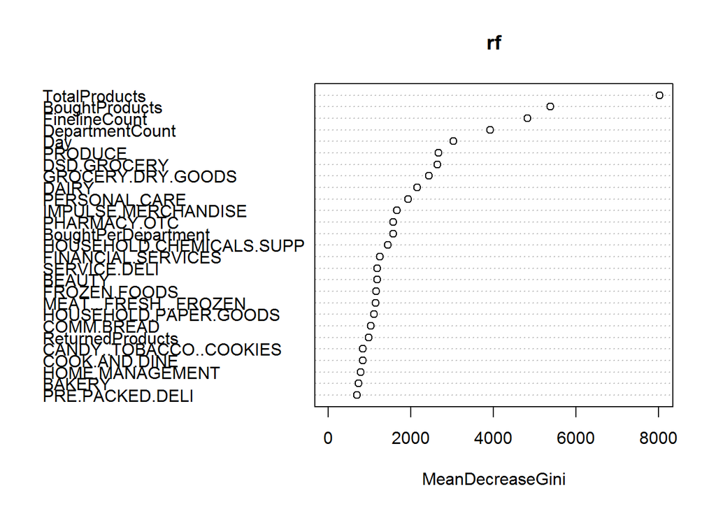

```r
scoresClass <- predict(rf, test, type = "class")
rfConfusionMatrix <- confusionMatrix(scoresClass, test$TripType)


varImpPlot(rf)
```

```r
importance(rf)
```

```
##                          MeanDecreaseGini
## Day                             3033.5541
## BoughtProducts                  5375.0270
## ReturnedProducts                 975.0281
## TotalProducts                   8022.4435
## DepartmentCount                 3922.2518
## FinelineCount                   4820.4615
## BAKERY                           739.0768
## BEAUTY                          1183.7982
## CANDY..TOBACCO..COOKIES          830.2088
## COMM.BREAD                      1031.7733
## COOK.AND.DINE                    829.9795
## DAIRY                           2157.6956
## DSD.GROCERY                     2640.5144
## FINANCIAL.SERVICES              1252.5861
## FROZEN.FOODS                    1158.8005
## GROCERY.DRY.GOODS               2437.5577
## HOME.MANAGEMENT                  786.9023
## HOUSEHOLD.CHEMICALS.SUPP        1444.2966
## HOUSEHOLD.PAPER.GOODS           1101.8926
## IMPULSE.MERCHANDISE             1667.5575
## MEAT...FRESH...FROZEN           1148.4544
## PERSONAL.CARE                   1938.4242
## PHARMACY.OTC                    1576.7258
## PRE.PACKED.DELI                  697.4139
## PRODUCE                         2663.2915
## SERVICE.DELI                    1184.4534
## BoughtPerDepartment             1569.1308
```

## Random Forest top values by importance

```r
sortedImportance=order(-rf$importance[,1])
tops=rownames(rf$importance)[sortedImportance][1:15][1:15]

tops <- append(tops, "TripType")
tops
```

```
##  [1] "TotalProducts"            "BoughtProducts"
##  [3] "FinelineCount"            "DepartmentCount"
##  [5] "Day"                      "PRODUCE"
##  [7] "DSD.GROCERY"              "GROCERY.DRY.GOODS"
##  [9] "DAIRY"                    "PERSONAL.CARE"
## [11] "IMPULSE.MERCHANDISE"      "PHARMACY.OTC"
## [13] "BoughtPerDepartment"      "HOUSEHOLD.CHEMICALS.SUPP"
## [15] "FINANCIAL.SERVICES"       "TripType"
```

```r
subTrain <- train[tops]
subTest <- test[tops]

rfTop <- randomForest(TripType ~ ., data=subTrain)
scoresTop <- predict(rfTop, subTest, type = "prob")

myScoresTop <- sapply(1:nrow(subTest), function(i){
  scoresTop[i, subTest$TripType[i]]
})

perfTop <- mean(-log(pmax(myScoresTop,0.05)))
perfTop
```

```
## [1] 0.9022671
```

```r
scoresTopClass <- predict(rfTop, subTest, type = "class")
rfTopConfusionMatrix <- confusionMatrix(scoresTopClass, subTest$TripType)
```

# Results

```r
#Random Forest
rfConfusionMatrix#$overall
```

```
## Confusion Matrix and Statistics
##
##           Reference
## Prediction    3    4    5    6    7    8    9   12   14   15   18   19
##        3    345    0    1    0    0   11   10    0    0    1    2    3
##        4      0    8    0    0    0    0    0    0    0    0    0    0
##        5      0   26  422    5    4   44   14    1    0    1    2    4
##        6      0    0    0   55    0   11    7    0    0    0    0    0
##        7      0    0    1    7  946   64   18    3    0    7    0    2
##        8      0    1   34   36   71 1147  108    2    0    2    4    1
##        9     11    0  117   53   12  101  896    3    0    9   18   17
##        12     0    0    0    0    0    0    0   42    0    0    0    0
##        14     0    0    0    0    0    0    0    0    0    0    0    0
##        15     0    0    1    1    1    0    0    1    0  129    0    0
##        18     0    0    0    0    0    0    0    0    0    0   45    0
##        19     0    0    0    0    0    0    0    0    0    0    0   20
##        20     0    0    0    0    0    0    0    0    0    1    0    0
##        21     0    0    0    0    1    0    0    0    0    1    1    0
##        22     0    0    0    0    0    0    0    0    0    1    0    0
##        23     0    0    0    0    0    0    0    0    0    0    0    0
##        24     2    0    1    0    1    2    3    1    0    4    1    2
##        25     2    0   15    6    4    4   15    4    0   34   34    9
##        26     0    0    0    0    0    0    0    0    0    1    0    0
##        27     0    0    0    0    0    0    0    0    0    1    0    0
##        28     0    0    0    0    0    0    0    0    0    0    0    0
##        29     0    0    0    0    0    0    0    0    0    0    0    0
##        30     0    0    1    0    0    0    0    0    0    2    1    0
##        31     0    0    0    0    0    0    0    0    0    0    0    0
##        32     0    0    0    0    0    0    0    1    0    4    3    0
##        33     0    0    0    3    3    1    1    3    0    3    1    0
##        34     0    0    0    0    0    0    0    0    0    0    0    0
##        35     0    0    3    3   14    1    0    1    0   11    2    0
##        36     0    0   12    2    2    7    1    1    0    2    5    0
##        37     0    0    5    2   31    4    1    0    0    5    0    0
##        38     0    2    1    4   20   13    2    3    0    2    0    0
##        39     0    6   49   18   87    5    1   14    0   29    1    6
##        40     0    0    2    0    3    0    0    1    0    4    0    0
##        41     0    0    0    1    0    0    0    1    0    1    2    0
##        42     0    0    1    0    0    0    0    3    0    5    5    1
##        43     0    0    0    1    0    1    0    0    0    0    4    1
```

[output cut: 192 more lines]

```
## Pos Pred Value         0.83584    0.7767    0.9649  0.886364   0.74517
## Neg Pred Value         0.99012    0.9846    0.9979  0.996131   0.99174
## Prevalence             0.04290    0.1705    0.1855  0.010086   0.03118
## Detection Rate         0.03342    0.1583    0.1838  0.006243   0.02317
## Detection Prevalence   0.03998    0.2038    0.1905  0.007044   0.03110
## Balanced Accuracy      0.88603    0.9367    0.9914  0.809120   0.86754
##                      Class: 43 Class: 44 Class: 999
## Sensitivity           0.584098   0.83134    0.75198
## Specificity           0.998702   0.99909    0.99942
## Pos Pred Value        0.856502   0.96605    0.97935
## Neg Pred Value        0.994508   0.99478    0.99099
## Prevalence            0.013087   0.03014    0.03534
## Detection Rate        0.007644   0.02505    0.02657
## Detection Prevalence  0.008925   0.02593    0.02714
## Balanced Accuracy     0.791400   0.91522    0.87570
```

```r
#Random Forest Top variables by importance
rfTopConfusionMatrix#$overall
```

```
## Confusion Matrix and Statistics
##
##           Reference
## Prediction    3    4    5    6    7    8    9   12   14   15   18   19
##        3    346    0    1    0    1   12   10    0    0    1    2    3
##        4      0    6    0    0    0    0    0    0    0    0    0    0
##        5      0   27  413    5    6   51   15    2    0    1    1    5
##        6      0    0    0   17    2    0    0    0    0    0    0    0
##        7      1    0    1   15  451   16   12    4    0   20    1    0
##        8      0    2   28   41  174 1084  185    3    0    2    5    2
##        9     11    0  120   71  190  211  830    2    0   10   18   17
##        12     0    0    0    0    0    0    0   35    0    0    0    0
##        14     0    0    0    0    0    0    0    0    0    0    0    0
##        15     0    0    1    0    1    1    0    1    0   90    0    0
##        18     0    0    0    0    0    0    0    0    0    0   36    0
##        19     0    0    0    0    0    0    0    0    0    0    0   15
##        20     0    0    0    0    0    0    0    0    0    0    0    0
##        21     0    0    0    0    1    0    0    0    0    0    1    0
##        22     0    0    0    0    2    0    0    0    0    0    0    0
##        23     0    0    0    0    0    0    0    0    0    0    0    0
##        24     0    0    1    2   11    0    4    2    0    4    1    1
##        25     2    0   16   12   69   10   15   10    0   56   37   12
##        26     0    0    0    0    0    0    0    0    0    0    0    0
##        27     0    0    0    0    1    0    0    0    0    0    0    0
##        28     0    0    0    0    0    0    0    0    0    0    0    0
##        29     0    0    0    0    0    0    0    0    0    0    0    0
##        30     0    0    0    0    0    0    0    0    0    0    1    0
##        31     0    0    0    0    0    0    0    0    0    0    0    0
##        32     0    0    0    1    1    0    0    1    0    1    3    0
##        33     0    0    0    3    4    0    1    0    0    0    1    0
##        34     0    0    0    0    0    0    0    0    0    0    0    0
##        35     0    0    3    5   29    3    0    1    0    9    1    2
##        36     0    0   14    1    5    4    1    0    0    5    6    1
##        37     0    0    3    3   36    4    0    0    0    6    2    1
##        38     0    2    1    5   29   14    3    2    0    2    0    1
##        39     0    6   60   16  165    6    2   20    0   39   11    6
##        40     0    0    4    0    4    0    0    1    0    6    0    0
##        41     0    0    0    0    0    0    0    0    0    0    0    0
##        42     0    0    1    1   15    0    1    1    0    9    4    0
##        43     0    0    0    0    2    0    0    0    0    0    0    0
```

[output cut: 192 more lines]

```
## Pos Pred Value         0.81315    0.6993    0.9596  0.974576   0.63260
## Neg Pred Value         0.98781    0.9785    0.9976  0.994491   0.98928
## Prevalence             0.04290    0.1705    0.1855  0.010086   0.03118
## Detection Rate         0.03118    0.1537    0.1836  0.004603   0.02081
## Detection Prevalence   0.03834    0.2198    0.1913  0.004723   0.03290
## Balanced Accuracy      0.85960    0.9109    0.9901  0.728114   0.82752
##                      Class: 43 Class: 44 Class: 999
## Sensitivity           0.418960   0.80212    0.73499
## Specificity           0.998702   0.99839    0.99967
## Pos Pred Value        0.810651   0.93935    0.98782
## Neg Pred Value        0.992344   0.99388    0.99038
## Prevalence            0.013087   0.03014    0.03534
## Detection Rate        0.005483   0.02417    0.02597
## Detection Prevalence  0.006764   0.02573    0.02629
## Balanced Accuracy     0.708831   0.90026    0.86733
```

# Conclusions

The random forest using only top variables by importance performed worse and yields lower accuracy (~73%). For the other forest accuracy is 80% which is very good result.